# Time_Estimation_ME_and_MSE

[figure not shown]

### Modeling and Estimation of Delivery time

Alejandro Alemany  
[**Explore the docs »**](https://github.com/AlrxKali/Cornershop)  
Report Bug · Request Feature

#### Cornershop operates in more than 20 cities, reaching tens of thousands of orders per day. One key element to determine how many orders we can accept, when we must begin to work on an order and also, at which time can we promise delivery to the customer, is the time estimation.

## Below there is some Data cleaning and preparation to build the model. You might skip it until the end, where I will explain the results.

```python
import pandas as pd
import numpy as np
import matplotlib.pyplot as plt
import seaborn as sns
import statsmodels.api as sm
from statsmodels.tools.eval_measures import mse, rmse
from sklearn.model_selection import train_test_split
from sklearn.metrics import mean_absolute_error
```

```python
orders = pd.read_csv('orders.csv')
shoppers = pd.read_csv('shoppers.csv')
order_product = pd.read_csv('order_product.csv')
store = pd.read_csv('storebranch.csv')
```

```python
orders.head(5)
```

|  | order_id | lat | lng | dow | promised_time | actual_time | on_demand | picker_id | driver_id | store_branch_id | total_minutes |
| --- | --- | --- | --- | --- | --- | --- | --- | --- | --- | --- | --- |
| 0 | 6abd5e28d01b7c733fe37485294235dc | 18.221141 | -100.313914 | 2 | 13:00:00 | 12:00:15 | False | 09bb5bfe76adbb474dddbdd111a51623 | 09bb5bfe76adbb474dddbdd111a51623 | 0dc6fb5924a8b917bc641666ed02663c | 91.800861 |
| 1 | 0d37a1eea001f01b40232ffd496ff663 | 18.177712 | -100.357051 | 2 | 13:00:00 | 10:28:10 | False | c4c722114a82fa21654e57e9636d68b0 | c4c722114a82fa21654e57e9636d68b0 | 2bbf833e689d24b697f1f3529c3f3c4b | 206.599732 |
| 2 | 528428e9b9eb5d3bd0dbdd8da692b087 | 18.266832 | -100.317553 | 2 | 11:00:00 | 10:40:50 | False | e15c7a67d0ea9a54dffb410bc1d8528b | e15c7a67d0ea9a54dffb410bc1d8528b | 8d891dfc0e29d744c15c18adced74a68 | 93.458001 |
| 3 | d3f7be6d64eae7405b7bf024e04807a2 | 18.248884 | -100.322622 | 2 | 10:00:00 | 09:41:47 | False | d1f0bd4b237c1358f09db22076b940e7 | d1f0bd4b237c1358f09db22076b940e7 | 0dc6fb5924a8b917bc641666ed02663c | 124.778761 |
| 4 | e0ad6533b6cd9a382ec6c1d473c5036c | 18.229110 | -100.322672 | 2 | 11:00:00 | 10:07:53 | False | 06a71e8ab0c6db5ce22a4689fd76a3f4 | 06a71e8ab0c6db5ce22a4689fd76a3f4 | afd0a7b8d546fcc697bb93a5934b65c3 | 130.321208 |

```python
orders.info()
```

```
<class 'pandas.core.frame.DataFrame'>
RangeIndex: 7295 entries, 0 to 7294
Data columns (total 11 columns):
 #   Column           Non-Null Count  Dtype
---  ------           --------------  -----
 0   order_id         7295 non-null   object
 1   lat              7295 non-null   float64
 2   lng              7295 non-null   float64
 3   dow              7295 non-null   int64
 4   promised_time    7295 non-null   object
 5   actual_time      7295 non-null   object
 6   on_demand        7295 non-null   bool
 7   picker_id        7295 non-null   object
 8   driver_id        7295 non-null   object
 9   store_branch_id  7295 non-null   object
 10  total_minutes    6543 non-null   float64
dtypes: bool(1), float64(3), int64(1), object(6)
memory usage: 577.2+ KB
```

```python
orders['promised_time'] = orders['promised_time'].apply(lambda x: int(x.replace(":", "")))
```

```python
orders['actual_time'] = orders['actual_time'].apply(lambda x: int(x.replace(":", "")))
```

```python
orders = orders.drop(columns=['order_id', 'lat', 'lng', 'picker_id', 'driver_id', 'store_branch_id'])
```

```python
orders.info()
```

```
<class 'pandas.core.frame.DataFrame'>
RangeIndex: 7295 entries, 0 to 7294
Data columns (total 5 columns):
 #   Column         Non-Null Count  Dtype
---  ------         --------------  -----
 0   dow            7295 non-null   int64
 1   promised_time  7295 non-null   int64
 2   actual_time    7295 non-null   int64
 3   on_demand      7295 non-null   bool
 4   total_minutes  6543 non-null   float64
dtypes: bool(1), float64(1), int64(3)
memory usage: 235.2 KB
```

```python
orders.dropna(inplace=True)
```

```python
orders['on_demand'] = orders['on_demand'].apply(lambda x:  0 if (x == False) else 1)
```

```python
X = orders.drop(columns=['total_minutes','promised_time'])
orders = orders.drop(columns=['total_minutes'])
Y = orders['promised_time']
```

```python
x_train, x_test, y_train, y_test = train_test_split(X, Y, test_size = 0.2)
```

```python
x_train = sm.add_constant(x_train)
```

```python
results = sm.OLS(y_train, x_train).fit()
```

```python
print(results.summary())
```

```
                            OLS Regression Results
==============================================================================
Dep. Variable:          promised_time   R-squared:                       0.830
Model:                            OLS   Adj. R-squared:                  0.830
Method:                 Least Squares   F-statistic:                     8517.
Date:                Wed, 16 Dec 2020   Prob (F-statistic):               0.00
Time:                        13:21:45   Log-Likelihood:                -58374.
No. Observations:                5234   AIC:                         1.168e+05
Df Residuals:                    5230   BIC:                         1.168e+05
Df Model:                           3
Covariance Type:            nonrobust
===============================================================================
                  coef    std err          t      P>|t|      [0.025      0.975]
-------------------------------------------------------------------------------
const        1.966e+04    986.158     19.939      0.000    1.77e+04    2.16e+04
dow           -14.4689    134.670     -0.107      0.914    -278.478     249.541
actual_time     0.9183      0.006    159.050      0.000       0.907       0.930
on_demand   -3313.9296    477.646     -6.938      0.000   -4250.315   -2377.544
==============================================================================
Omnibus:                     8466.647   Durbin-Watson:                   1.998
Prob(Omnibus):                  0.000   Jarque-Bera (JB):          5818610.530
Skew:                         -10.594   Prob(JB):                         0.00
Kurtosis:                     164.962   Cond. No.                     6.70e+05
==============================================================================

Warnings:
[1] Standard Errors assume that the covariance matrix of the errors is correctly specified.
[2] The condition number is large, 6.7e+05. This might indicate that there are
strong multicollinearity or other numerical problems.
```

```python
x_test = sm.add_constant(x_test)
```

```python
y_preds = results.predict(x_test)
```

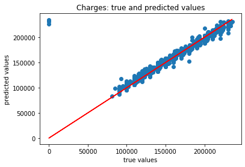

```python
plt.scatter(y_test, y_preds)
plt.plot(y_test, y_test, color="red")
plt.xlabel("true values")
plt.ylabel("predicted values")
plt.title("Charges: true and predicted values")
plt.show()
```

```python
print("Mean absolute error of the prediction is: {}".format(mean_absolute_error(y_test, y_preds)))
print("Mean squared error of the prediction is: {}".format(mse(y_test, y_preds)))
print("Root mean squared error of the prediction is: {}".format(rmse(y_test, y_preds)))
```

```
Mean absolute error of the prediction is: 4960.128761212317
Mean squared error of the prediction is: 192464288.42658353
Root mean squared error of the prediction is: 13873.14991004507
```

### The model predicts the higher values of the target better than it predicts the lower values. The goodness of fit is 83%, but I suspect the model is overfitting the data. The values from ME and MSE are very high, so the model has a higher degree of randomness. However, These values are useful if we compare them with other models and the same metrics. So far, this model will have a better performance when predicting higher values.